# Worksheet 3

Gabriel Singer

15.02.2023

## Stoichiometry of microbes

[Hall et al. (2010)](https://www.nature.com/articles/ismej2010115) report microbial biomass stoichiometry measured on a per cell basis using Raman microspectroscopy. The experiment uses 2 species measured in 2 growth phases on 4 media differing in stoichiometry. Verrucomicroba are slow-growing soil and limnic bacteria, Pectobacterium is an opportunistic fast-growing detritivore isolated from carrots. The experiment is a complete full-factorial design and the original work actually has even a fourth factor in the design (which we here ignore). There are independently replicated bottles for each cell of the design, but replication is a bit various. Extreme N:P media (0.5 and 500) are replicated a bit less than the intermediate N:P levels 5 and 50. In addition, in each bottle 20 specimens were actually measured under the microscope. The factor `all.treat` is a *combined* factor created by **bacterium_phase_medium_bottle** and codes for the independent replicates in the experimental design.

The response variables in this design are signatures extracted from Raman spectra collected from individual bacterial cells. These are proxies for specific macromolecules: 8 carbohydrates, 4 nucleic acids, 3 proteins (coded by `ca_` and `na_`, `pr_`.)

```r
mic = read.table("data/MicrobesStoichiometry.txt", header = TRUE)
levels(mic$species)<-c("Pec","Ver") # just to make shorter labels on axes
names(mic)
```

```
##  [1] "bottle"    "scan"      "species"   "phase"     "NP"        "all.treat"
##  [7] "ca_1"      "ca_2"      "ca_3"      "ca_4"      "ca_5"      "ca_6"
## [13] "ca_7"      "ca_8"      "na_1"      "na_2"      "na_3"      "na_4"
## [19] "pr_1"      "pr_2"      "pr_3"
```

1. The dataset is fairly large ;-), i.e. *exploration* could take you a while. Therefore start with filtering a subset of intermediate stoichiometry in the medium (either level 5 or 50).

```r
mic$NP<-factor(mic$NP)
mic<-subset(mic,subset=(NP==5) )
mic<-droplevels(mic)
```

2. The dataset is multivariate, we are mainly interested in aabundance of *nucleic acids*. Could all the nucleic acid Raman signatures be considered to inform about the same property *nucleic acid abundance*? If so, average the signatures to create a new *metavariable*. Consider using `scale` before averaging.

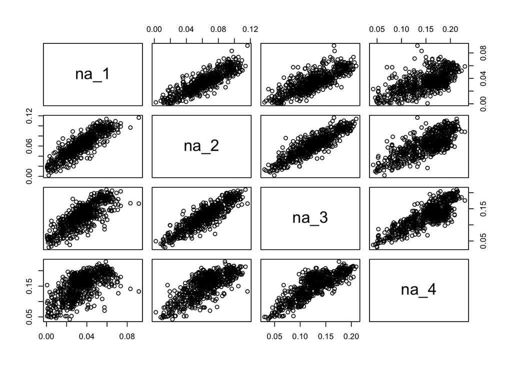

```r
plot(mic[,grep("na",names(mic))])
```

```r
# strong correlations suggest redundant information in those na-signatures
mic$na_avg<-apply(scale(mic[,grep("na",names(mic))]),1,mean)
# this is a good average na-signature, due to scaling all 4 have same weight
```

3. Measurements of individual bacterial cells are replicates **within** each bottle. The experimental design in fact requires a mixed model analysis that accounts for the dependency of measurements within each bottle. As an alternative, the dataset could be collapsed to the level it is actually independently replicated, i.e. the bottle. This could be done by computing means per bottle, forming a new dataset with only 1 *average* bacterium per bottle. It may be worthwhile to explore distribution of measurements within a bottle - maybe a different measure should be used to get an average *location*. Not collapsing the dataset to bottle means would mean to use a **pseudoreplicated** dataset.

```r
# could check distribution within each bottle
i<-0
i<-i+1
levels(mic$bottle)
```

```
##  [1] "E12L1" "E12L2" "E12S1" "E12S2" "E3L1"  "E3L2"  "E3S1"  "E3S3"  "E6L1"
## [10] "E6L2"  "E6S1"  "E6S2"  "E9L1"  "E9L2"  "E9S1"  "E9S2"  "V12L1" "V12L2"
## [19] "V12S1" "V12S3" "V3L1"  "V3L2"  "V3S1"  "V3S2"  "V6L1"  "V6L2"  "V6S1"
## [28] "V6S2"  "V9L1"  "V9L2"  "V9S1"  "V9S2"
```

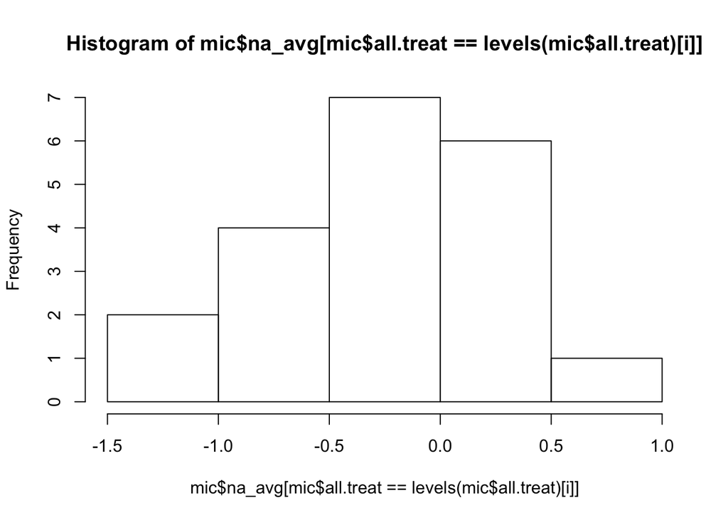

```r
hist(mic$na_avg[mic$all.treat==levels(mic$all.treat)[i]])
```

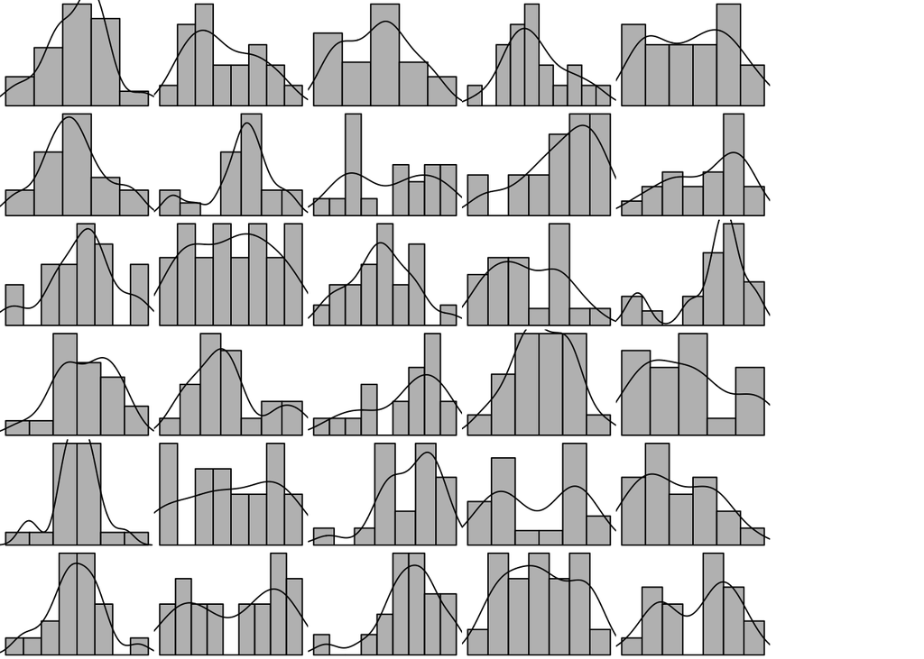

```r
# just rerun last two lines to get some histograms
# could also just plot all 60 or maybe at least some of them
layout(matrix(1:36,nrow=6,ncol=6))
old.par<-par # to keep graphical pars
par(mar=c(0,0,0,0))
for(i in 1:30) {
  hist(mic$na_avg[mic$all.treat==levels(mic$all.treat)[i]],xlab="",ylab="",main="",xaxt="n",yaxt="n",col="grey",freq=FALSE)
  lines(density(mic$na_avg[mic$all.treat==levels(mic$all.treat)[i]]))
}
# not all bottles generate ND data, maybe median is better measure for location within each bottle than mean
# now averaging data within each bottle
na_bt_med<-tapply(mic$na_avg,INDEX=mic$all.treat,median)
species<-factor(substr(names(na_bt_med),start=0,stop=3))
phase<-factor(substr(names(na_bt_med),start=5,stop=7))
mic1<-data.frame(species,phase,na_bt_med) # not used any further here

# same operation smarter with aggregate() instead
mic<-mic[,-2] # individual scan id, aggregation will make this factor meaningless
mic2<-aggregate(.~all.treat+species+phase+NP+bottle,data=mic,FUN=median)
# compare shape and size of mic vs. mic2!
```

4. The growth rate hypothesis links stoichiometry of biomass, specifically the amount of P relative to N or C, to growth rate of organisms. Small, fast growing organisms have lower C:P and N:P ratios as higher growth means more “growth machinery” = ribosomes, that contain a lot of P. Consequently, microbial cells growing exponentially should have higher nucleic acid content. Test whether this is true for the two bacterial species and create an appropriate graph showing differences in means.

```r
# could do separate tests for each species, but two-way ANOVA is more efficient and could help to find an interesting interaction effect
combfac<-paste(mic2$species,mic2$phase,sep="_")
bartlett.test(mic2$na_avg~combfac)
```

```
##
##  Bartlett test of homogeneity of variances
##
## data:  mic2$na_avg by combfac
## Bartlett's K-squared = 4.8878, df = 3, p-value = 0.1802
```

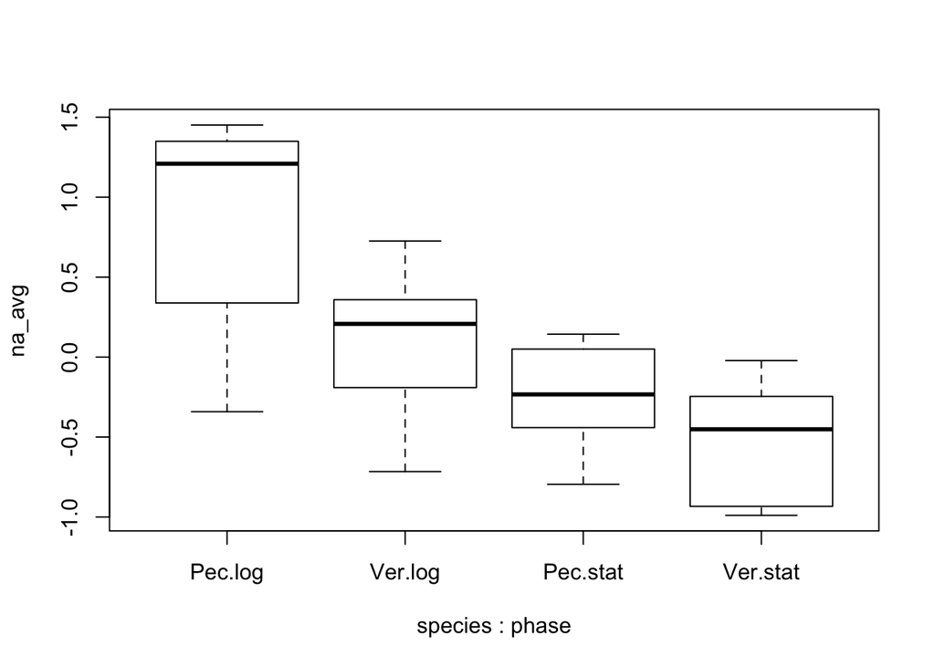

```r
boxplot(na_avg~species*phase,data=mic2)
```

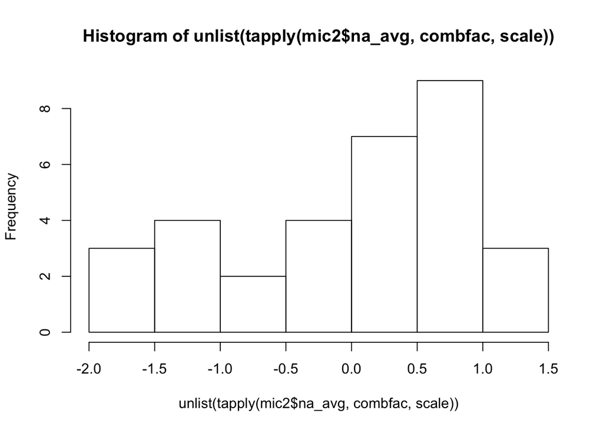

```r
# --> variances assumed as homogeneous
hist(unlist(tapply(mic2$na_avg,combfac,scale))) # quick and dirt check says ND may be given ;-)
```

```r
an<-aov(na_avg~species*phase,data=mic2)
summary(an)
```

```
##               Df Sum Sq Mean Sq F value   Pr(>F)
## species        1  2.265   2.265   9.408  0.00475 **
## phase          1  5.983   5.983  24.857 2.88e-05 ***
## species:phase  1  0.444   0.444   1.846  0.18508
## Residuals     28  6.739   0.241
## ---
## Signif. codes:  0 '***' 0.001 '**' 0.01 '*' 0.05 '.' 0.1 ' ' 1
```

```r
# interaction not significant, thus in principal no post-hoc tests needed unless groupwise comparisons interesting
TukeyHSD(an)
```

```
##   Tukey multiple comparisons of means
##     95% family-wise confidence level
##
## Fit: aov(formula = na_avg ~ species * phase, data = mic2)
##
## $species
##               diff        lwr        upr     p adj
## Ver-Pec -0.5320366 -0.8873434 -0.1767297 0.0047528
##
## $phase
##                diff       lwr        upr    p adj
## stat-log -0.8647926 -1.220099 -0.5094857 2.88e-05
##
## $`species:phase`
##                         diff        lwr         upr     p adj
## Ver:log-Pec:log   -0.7677138 -1.4374665 -0.09796109 0.0200076
## Pec:stat-Pec:log  -1.1004698 -1.7702225 -0.43071707 0.0006194
## Ver:stat-Pec:log  -1.3968291 -2.0665818 -0.72707643 0.0000238
## Pec:stat-Ver:log  -0.3327560 -1.0025087  0.33699673 0.5360806
## Ver:stat-Ver:log  -0.6291153 -1.2988680  0.04063738 0.0714536
## Ver:stat-Pec:stat -0.2963594 -0.9661121  0.37339336 0.6269465
```

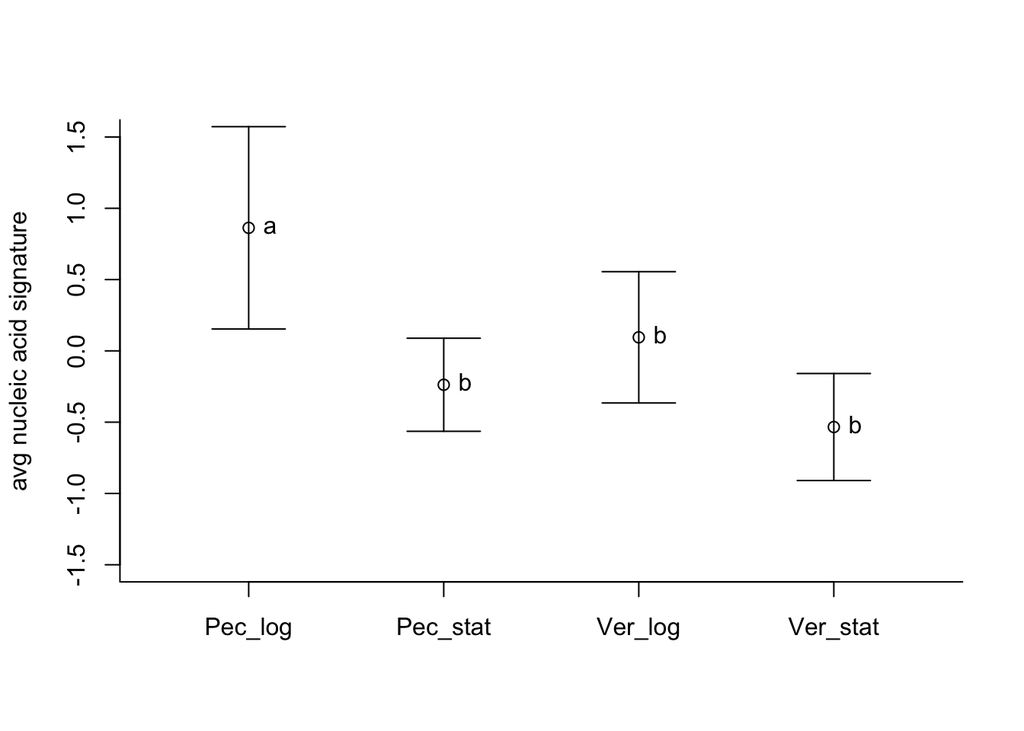

```r
# making an appropriate graph
# Anova tests differences in locations=means, thus boxplots are not really appropriate
means<-tapply(mic2$na_avg,combfac,mean)
sds<-tapply(mic2$na_avg,combfac,sd)
plot(c(1:4),means,xlim=c(0.5,4.5),ylim=c(-1.5,1.5),ylab="avg nucleic acid signature", xlab="",xaxt="n",bty="l")
arrows(x0=c(1:4),y0=means-sds,y1=means+sds,angle=90,code=3)
axis(side=1,at=c(1:4),labels=names(means))
text(c(1:4),means,labels=c("a","b","b","b"),pos=4)
```

```r
# obvious some things could still be improved, like using different symbols and symbol colors for the treatments
```

Conclude: ANOVA results show significant main effects and no interaction. The interaction term is just not significant, so we should better be careful with interpreting the main effects. Also, the plot suggests quite different patterns and prompts us to rely on pairwise tests rather than the anova results. The opportunistic species has clearly higher nucleic acid content when in growth phase.

5. Assume nucleic acid abundance as indicating growth. Can both bacterial species translate increased availability of P equally well into more growth? Use the N:P levels 5 and 50 and data from the logarithmic growth phase.

```r
mic = read.table("data/MicrobesStoichiometry.txt", header = TRUE)
levels(mic$species)<-c("Pec","Ver") # just to make shorter labels on axes
mic$NP<-factor(mic$NP)
mic<-subset(mic,subset=((NP==5 | NP==50) & phase=="log"))
mic<-droplevels(mic)
mic$na_avg<-apply(scale(mic[,grep("na",names(mic))]),1,mean)
mic<-mic[,-c(2)]
mic_agg<-aggregate(.~all.treat+species+phase+NP+bottle,data=mic,FUN=median)
mic_agg$combfac<-paste(substr(mic_agg$species,0,3),mic_agg$NP,sep="_")

table(mic_agg$combfac)
```

```
##
##  Pec_5 Pec_50  Ver_5 Ver_50
##      8      8      8      6
```

```r
bartlett.test(na_avg~combfac,data=mic_agg)
```

```
##
##  Bartlett test of homogeneity of variances
##
## data:  na_avg by combfac
## Bartlett's K-squared = 2.6513, df = 3, p-value = 0.4486
```

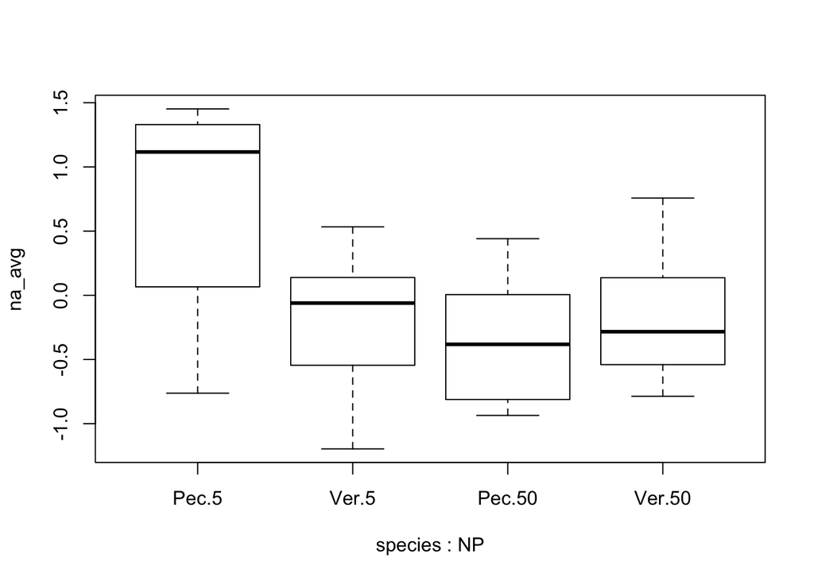

```r
boxplot(na_avg~species*NP,data=mic_agg)
```

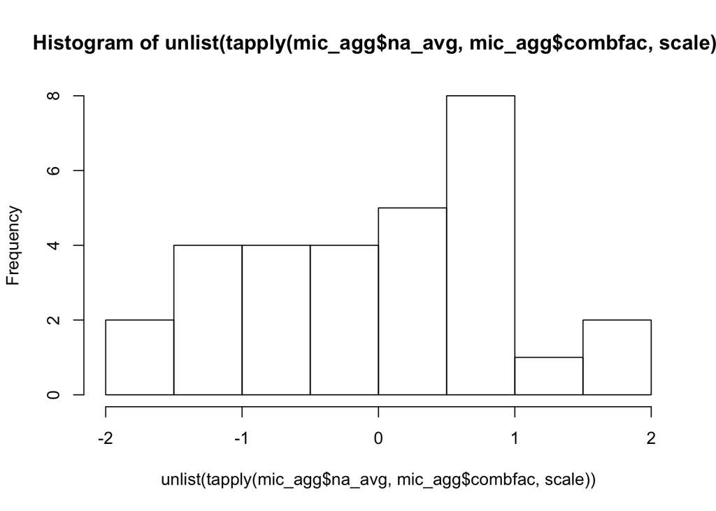

```r
# variances seem homogeneous
hist(unlist(tapply(mic_agg$na_avg,mic_agg$combfac,scale))) # ok
```

```r
an<-aov(na_avg~species*NP,data=mic_agg)
summary(an)
```

```
##             Df Sum Sq Mean Sq F value Pr(>F)
## species      1  0.984  0.9842   2.350 0.1373
## NP           1  2.351  2.3506   5.613 0.0255 *
## species:NP   1  2.258  2.2578   5.392 0.0283 *
## Residuals   26 10.888  0.4188
## ---
## Signif. codes:  0 '***' 0.001 '**' 0.01 '*' 0.05 '.' 0.1 ' ' 1
```

```r
# interaction significant
# thus post-hoc tests more important
TukeyHSD(an)
```

```
##   Tukey multiple comparisons of means
##     95% family-wise confidence level
##
## Fit: aov(formula = na_avg ~ species * NP, data = mic_agg)
##
## $species
##               diff        lwr       upr     p adj
## Ver-Pec -0.3630609 -0.8498554 0.1237336 0.1373417
##
## $NP
##            diff       lwr        upr     p adj
## 50-5 -0.5596476 -1.046442 -0.0728531 0.0258792
##
## $`species:NP`
##                      diff        lwr         upr     p adj
## Ver:5-Pec:5   -0.91365173 -1.8012813 -0.02602212 0.0419343
## Pec:50-Pec:5  -1.07292860 -1.9605582 -0.18529899 0.0134842
## Ver:50-Pec:5  -0.88068976 -1.8394393  0.07805979 0.0801310
## Pec:50-Ver:5  -0.15927687 -1.0469065  0.72835274 0.9601202
## Ver:50-Ver:5   0.03296196 -0.9257876  0.99171151 0.9996912
## Ver:50-Pec:50  0.19223883 -0.7665107  1.15098838 0.9456976
```

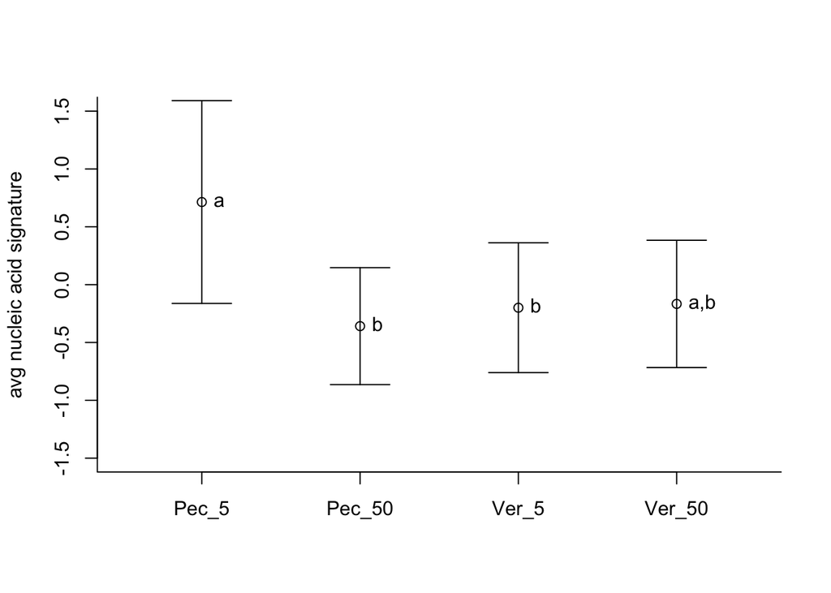

```r
# making an appropriate graph
# Anova tests differences in locations=means, thus boxplots are not really appropriate
means<-tapply(mic_agg$na_avg,mic_agg$combfac,mean)
sds<-tapply(mic_agg$na_avg,mic_agg$combfac,sd)
plot(c(1:4),means,xlim=c(0.5,4.5),ylim=c(-1.5,1.5),ylab="avg nucleic acid signature",xlab="",xaxt="n",bty="l")
arrows(x0=c(1:4),y0=means-sds,y1=means+sds,angle=90,code=3)
axis(side=1,at=c(1:4),labels=names(means))
text(c(1:4),means,labels=c("a","b","b","a,b"),pos=4)
```

```r
# obvious some things could still be improved, like using different symbols and symbol colors for the treatments
```

Conclude that the opportunistic species can make better use of high-P medium.

## Hucho record captures in Austrian rivers

Fishermen like to catch record-breaking large fish and if successful will do a bit of effort to document their historic achievement in the local pub ;-) This dataset contains sizes of such record catches of Hucho in various Austrian streams and rivers of various size, the data was collected from various sources including the eventual black-and-white photograph hanging in a pub.

Here is one such picture from the author of the study:

[figure not shown]

The Danube salmon is an endangered species in now dwindling populations. It needs intact river corridors for migration. Hydropower facilities should have a fish ladder allowing the fish to bypass turbines. The size of such a fish ladder is a cost issue AND an ecological issue - it needs to be large enough to accommodate the expected fish size in any given system. Usually large rivers host large fish. So, river size could be taken as a proxy of fish size to be expected.

```r
hucho = read.table("data/HuchoRatschan2012.txt", header = TRUE)
```

1. Look for a reasonable relationship of a river size measure with a fish size measure. Deliver a model that could guide construction of fish passes. Consider transformations to linearize relationships.

```r
names(hucho)
```

```
## [1] "river"      "population" "length"     "mass"       "discharge"
## [6] "width"
```

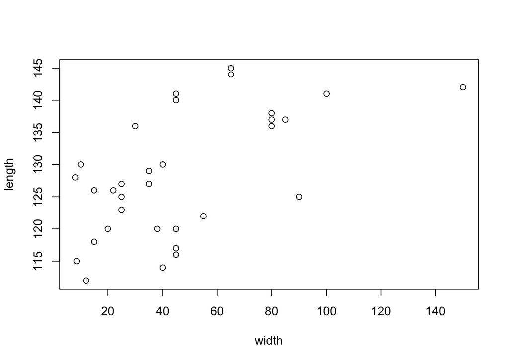

```r
plot(length~width,data=hucho)
```

```r
plot(mass~log(discharge),data=hucho) # I go for this one, but several others may also make sense
humo1<-lm(mass~log(discharge),data=hucho)
summary(humo1)
```

```
##
## Call:
## lm(formula = mass ~ log(discharge), data = hucho)
##
## Residuals:
##     Min      1Q  Median      3Q     Max
## -8.0650 -3.7538  0.5911  2.5827  9.0719
##
## Coefficients:
##                Estimate Std. Error t value Pr(>|t|)
## (Intercept)     14.8898     1.9967   7.457  2.6e-08 ***
## log(discharge)   2.4026     0.5433   4.422 0.000118 ***
## ---
## Signif. codes:  0 '***' 0.001 '**' 0.01 '*' 0.05 '.' 0.1 ' ' 1
##
## Residual standard error: 4.908 on 30 degrees of freedom
## Multiple R-squared:  0.3946, Adjusted R-squared:  0.3744
## F-statistic: 19.56 on 1 and 30 DF,  p-value: 0.0001184
```

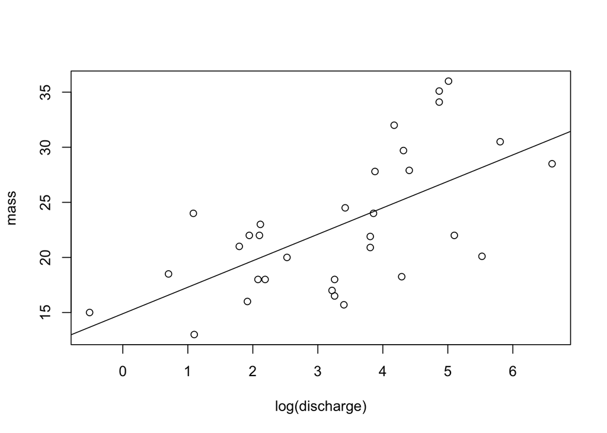

```r
abline(humo1)
```

```r
coef(humo1)
```

```
##    (Intercept) log(discharge)
##       14.88982        2.40255
```

Hucho model1: fish mass = 14.9+2.4 * log(Q)

2. A potential confounding variable could be population size. When a population of Hucho is very small, it is less likely to contain large specimens. The dataset includes an estimate of population size based on expert (= fishermen) opinion. Explore differences in maximum Hucho body size captured in the various systems depending on population size. Test for differences and produce a publishable final graph showing average maximum fish size in dependence from population size. Don´t forget to check assumptions before running your statistical analysis and justify your choice of method.

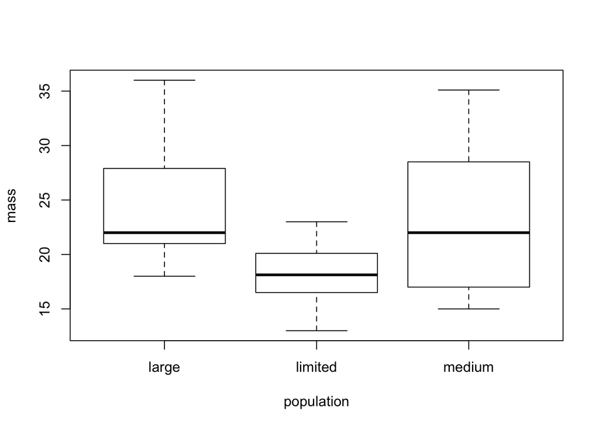

```r
boxplot(mass~population,data=hucho)
```

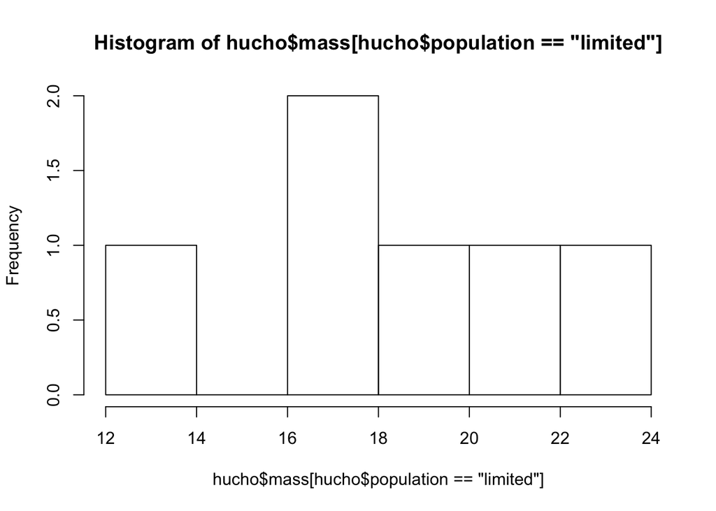

```r
# anova-problem
hist(hucho$mass[hucho$population=="limited"]) # ND will anyway be hard to judge...
```

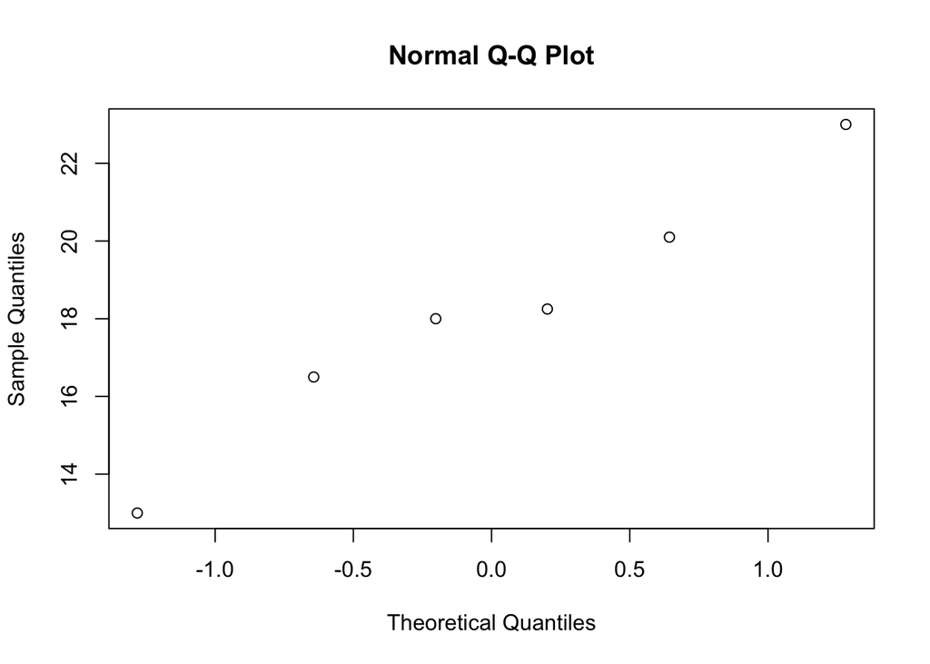

```r
qqnorm(hucho$mass[hucho$population=="limited"])
```

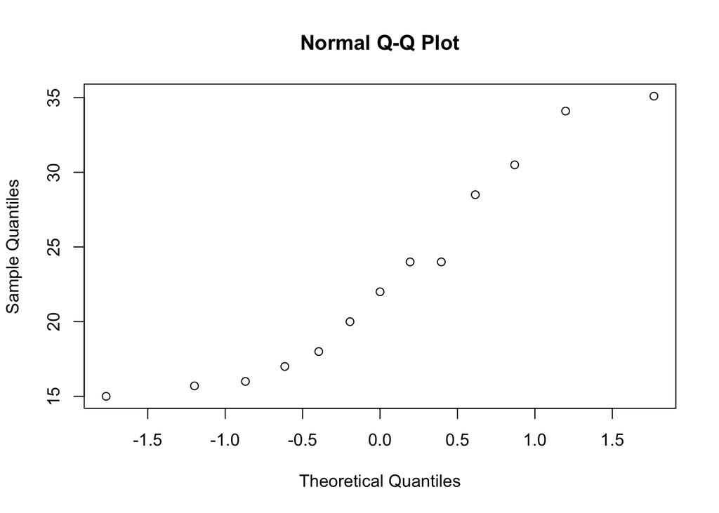

```r
qqnorm(hucho$mass[hucho$population=="medium"])
```

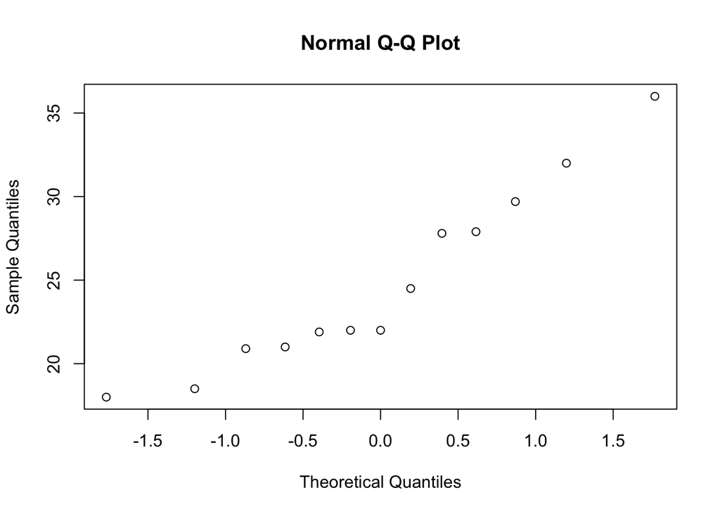

```r
qqnorm(hucho$mass[hucho$population=="large"])
```

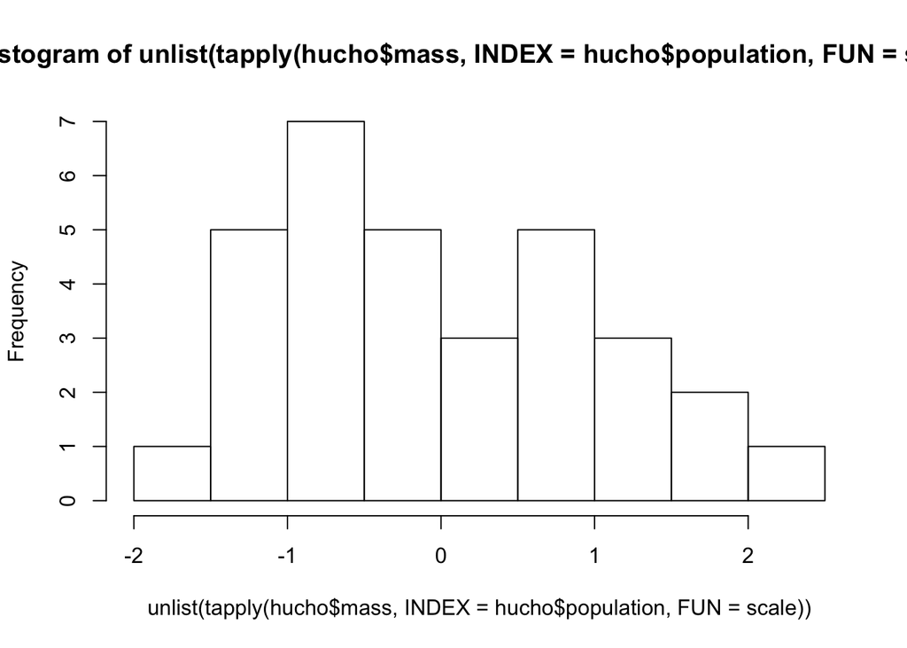

```r
hist(unlist(tapply(hucho$mass,INDEX=hucho$population,FUN=scale)))
```

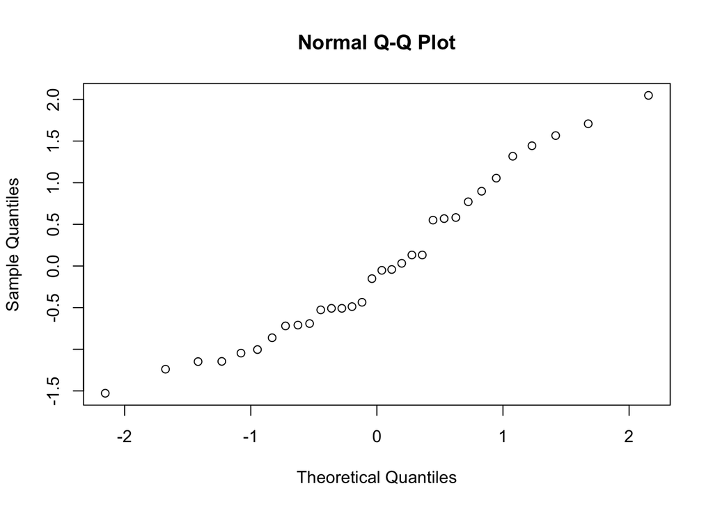

```r
qqnorm(unlist(tapply(hucho$mass,INDEX=hucho$population,FUN=scale)))
```

```r
shapiro.test(unlist(tapply(hucho$mass,INDEX=hucho$population,FUN=scale))) # check ND
```

```
##
##  Shapiro-Wilk normality test
##
## data:  unlist(tapply(hucho$mass, INDEX = hucho$population, FUN = scale))
## W = 0.95183, p-value = 0.1624
```

```r
bartlett.test(mass~population,data=hucho) # check var.hom.
```

```
##
##  Bartlett test of homogeneity of variances
##
## data:  mass by population
## Bartlett's K-squared = 3.0522, df = 2, p-value = 0.2174
```

```r
humo2<-lm(mass~population,data=hucho)
summary(humo2)
```

```
##
## Call:
## lm(formula = mass ~ population, data = hucho)
##
## Residuals:
##     Min      1Q  Median      3Q     Max
## -8.0692 -4.1808 -0.6769  3.5511 12.0308
##
## Coefficients:
##                   Estimate Std. Error t value Pr(>|t|)
## (Intercept)         24.785      1.638  15.130 2.69e-15 ***
## populationlimited   -6.643      2.915  -2.279   0.0302 *
## populationmedium    -1.715      2.317  -0.740   0.4650
## ---
## Signif. codes:  0 '***' 0.001 '**' 0.01 '*' 0.05 '.' 0.1 ' ' 1
##
## Residual standard error: 5.906 on 29 degrees of freedom
## Multiple R-squared:  0.1527, Adjusted R-squared:  0.09425
## F-statistic: 2.613 on 2 and 29 DF,  p-value: 0.0905
```

```r
anova(humo2)
```

```
## Analysis of Variance Table
##
## Response: mass
##            Df  Sum Sq Mean Sq F value Pr(>F)
## population  2  182.29  91.144  2.6129 0.0905 .
## Residuals  29 1011.61  34.883
## ---
## Signif. codes:  0 '***' 0.001 '**' 0.01 '*' 0.05 '.' 0.1 ' ' 1
```

```r
# Anova population size does not affect fish size significantly
pairwise.t.test(hucho$mass,hucho$population,method="bonferroni",pool.sd=TRUE)
```

```
##
##  Pairwise comparisons using t tests with pooled SD
##
## data:  hucho$mass and hucho$population
##
##         large limited
## limited 0.091 -
## medium  0.465 0.203
##
## P value adjustment method: holm
```

```r
# pairwise no significant difference!
```

Population size does not significantly influence maximum fish size (F=2.6, df1=2, df2=29, P=0.09), but there is a tendency for the limited populations to have smaller fish on average.

3. You will find that both river size and population size affect maximum Hucho size. How can you test both predictors at once? Which would be the best model for fish ladder builders if they wanted to improve the conservation status of Danube salmon in the future?

```r
hucho$population<-factor(hucho$population)
levels(hucho$population) # check order of levels
```

```
## [1] "large"   "limited" "medium"
```

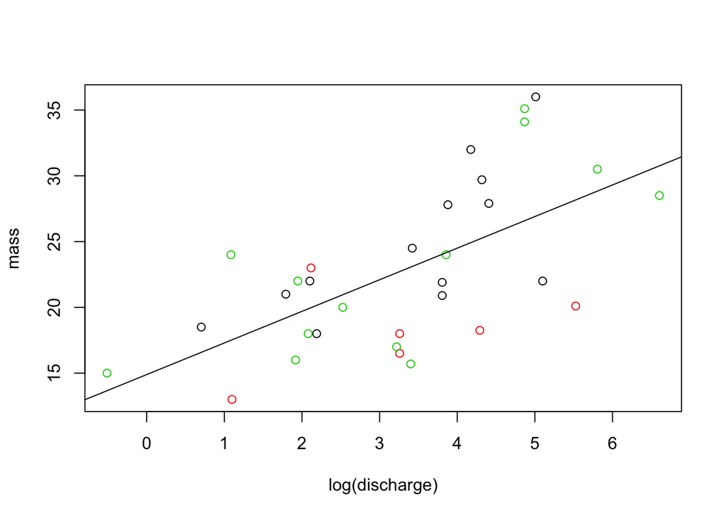

```r
plot(mass~log(discharge),data=hucho,col=hucho$population)
abline(humo1)
```

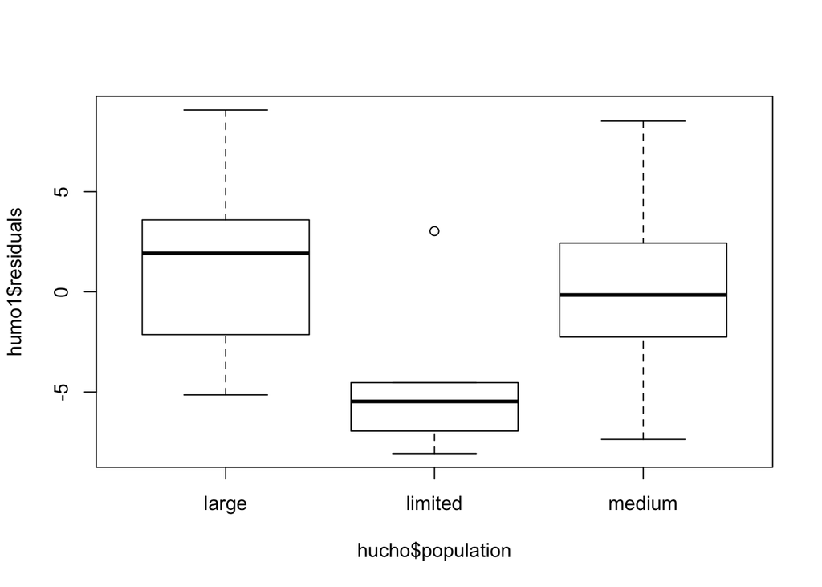

```r
boxplot(humo1$residuals~hucho$population) # this residual analysis strongly hints at an effect of population!
```

```r
humo3<-lm(mass~log(discharge)*population,data=hucho)

summary(humo3)
```

```
##
## Call:
## lm(formula = mass ~ log(discharge) * population, data = hucho)
##
## Residuals:
##     Min      1Q  Median      3Q     Max
## -7.8704 -3.2566 -0.0332  1.8738  7.7866
##
## Coefficients:
##                                  Estimate Std. Error t value Pr(>|t|)
## (Intercept)                       15.1644     3.5591   4.261 0.000236 ***
## log(discharge)                     2.7973     0.9694   2.886 0.007753 **
## populationlimited                  0.2723     5.7999   0.047 0.962911
## populationmedium                  -0.2760     4.3105  -0.064 0.949445
## log(discharge):populationlimited  -1.9670     1.6120  -1.220 0.233328
## log(discharge):populationmedium   -0.2446     1.1679  -0.209 0.835716
## ---
## Signif. codes:  0 '***' 0.001 '**' 0.01 '*' 0.05 '.' 0.1 ' ' 1
##
## Residual standard error: 4.494 on 26 degrees of freedom
## Multiple R-squared:  0.5602, Adjusted R-squared:  0.4757
## F-statistic: 6.624 on 5 and 26 DF,  p-value: 0.0004239
```

```r
anova(humo3)
```

```
## Analysis of Variance Table
##
## Response: mass
##                           Df Sum Sq Mean Sq F value    Pr(>F)
## log(discharge)             1 471.13  471.13 23.3305 5.261e-05 ***
## population                 2 163.37   81.68  4.0450   0.02955 *
## log(discharge):population  2  34.36   17.18  0.8508   0.43863
## Residuals                 26 525.04   20.19
## ---
## Signif. codes:  0 '***' 0.001 '**' 0.01 '*' 0.05 '.' 0.1 ' ' 1
```

```r
humo4<-lm(mass~log(discharge)+population,data=hucho)
anova(humo4)
```

```
## Analysis of Variance Table
##
## Response: mass
##                Df Sum Sq Mean Sq F value   Pr(>F)
## log(discharge)  1 471.13  471.13 23.5818 4.11e-05 ***
## population      2 163.37   81.68  4.0886  0.02768 *
## Residuals      28 559.40   19.98
## ---
## Signif. codes:  0 '***' 0.001 '**' 0.01 '*' 0.05 '.' 0.1 ' ' 1
```

```r
summary(humo4)
```

```
##
## Call:
## lm(formula = mass ~ log(discharge) + population, data = hucho)
##
## Residuals:
##     Min      1Q  Median      3Q     Max
## -7.8325 -2.7893 -0.0949  1.9198  8.1081
##
## Coefficients:
##                   Estimate Std. Error t value Pr(>|t|)
## (Intercept)        16.6708     2.1084   7.907 1.30e-08 ***
## log(discharge)      2.3593     0.4959   4.758 5.38e-05 ***
## populationlimited  -6.2152     2.2079  -2.815  0.00883 **
## populationmedium   -1.1626     1.7570  -0.662  0.51357
## ---
## Signif. codes:  0 '***' 0.001 '**' 0.01 '*' 0.05 '.' 0.1 ' ' 1
##
## Residual standard error: 4.47 on 28 degrees of freedom
## Multiple R-squared:  0.5315, Adjusted R-squared:  0.4812
## F-statistic: 10.59 on 3 and 28 DF,  p-value: 7.988e-05
```

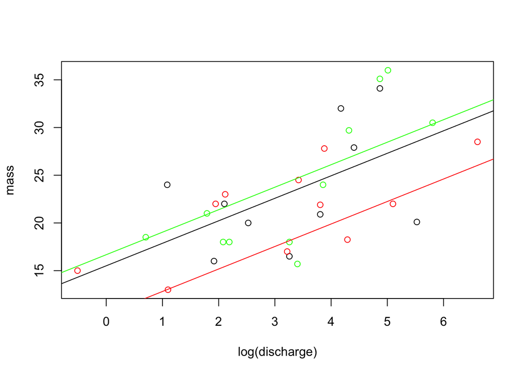

```r
plot(mass~log(discharge),data=hucho,col=c("green","red","black"))
abline(a=coef(humo4)[1],b=coef(humo4)[2],col="green")
abline(a=coef(humo4)[1]+coef(humo4)[3],b=coef(humo4)[2],col="red")
abline(a=coef(humo4)[1]+coef(humo4)[4],b=coef(humo4)[2],col="black")
```

The best model to estimate fish ladder dimension comes from mass~log(Q) using only data from large populations:

Hucho model4: Fish mass = 16.67 +2.36 log(Q)

which has similar slope but higher intercept than the model that ignores population size:

Hucho model1: Fish mass = 14.9+2.4 * log(Q)

With model1 fish would be estimated too small, fish passes would not support the largest fish that we could hope for in eventually healthy populations.